# Chapter 12: Multivariate Regression

Elias DeLeon

4/7/2020

```r
glimpse(x)
```

```
## Observations: 797
## Variables: 9
## $ name      <chr> "Abilene Christian University", "Adelphi University", "Ag...
## $ tier      <int> 6, 6, 4, 5, 5, 6, 6, 6, 6, 6, 6, 6, 6, 6, 4, 2, 8, 6, 5, ...
## $ tier_name <chr> "Selective private", "Selective private", "Highly selecti...
## $ type      <int> 2, 2, 2, 1, 1, 2, 2, 2, 2, 2, 2, 2, 2, 2, 2, 2, 2, 2, 1, ...
## $ public    <int> 0, 0, 0, 1, 1, 0, 0, 0, 0, 0, 0, 0, 0, 0, 0, 0, 0, 0, 1, ...
## $ earnings  <dbl> 40200.00, 50600.00, 39400.00, 27800.00, 32700.00, 52200.0...
## $ sat       <dbl> 1100.00, 1065.00, 1185.00, 800.00, 900.00, 1010.00, 1150....
## $ faculty   <dbl> 48039.76, 55523.10, 56078.15, 45691.52, 45164.08, 45315.0...
## $ price     <dbl> 10910.000, 15690.000, 16745.000, 2520.000, 2398.000, 1477...
```

```r
skim(x)
```

Data summary

| Name | x |
| --- | --- |
| Number of rows | 797 |
| Number of columns | 9 |
| _______________________ |  |
| Column type frequency: |  |
| character | 2 |
| numeric | 7 |
| ________________________ |  |
| Group variables | None |

**Variable type: character**

| skim_variable | n_missing | complete_rate | min | max | empty | n_unique | whitespace |
| --- | --- | --- | --- | --- | --- | --- | --- |
| name | 0 | 1 | 11 | 141 | 0 | 797 | 0 |
| tier_name | 0 | 1 | 8 | 45 | 0 | 10 | 0 |

**Variable type: numeric**

| skim_variable | n_missing | complete_rate | mean | sd | p0 | p25 | p50 | p75 | p100 | hist |
| --- | --- | --- | --- | --- | --- | --- | --- | --- | --- | --- |
| tier | 0 | 1 | 5.27 | 1.46 | 1.00 | 5.00 | 6.00 | 6.00 | 10.0 | ▁▁▇▁▁ |
| type | 0 | 1 | 1.69 | 0.48 | 1.00 | 1.00 | 2.00 | 2.00 | 3.0 | ▃▁▇▁▁ |
| public | 0 | 1 | 0.32 | 0.47 | 0.00 | 0.00 | 0.00 | 1.00 | 1.0 | ▇▁▁▁▃ |
| earnings | 0 | 1 | 45129.97 | 10694.32 | 25500.00 | 38400.00 | 43200.00 | 49200.00 | 116400.0 | ▇▆▁▁▁ |
| sat | 0 | 1 | 1080.27 | 128.87 | 775.00 | 990.00 | 1060.00 | 1160.00 | 1520.0 | ▂▇▆▂▁ |
| faculty | 0 | 1 | 55207.37 | 13491.15 | 22043.62 | 46128.28 | 52828.56 | 63393.43 | 116117.4 | ▂▇▃▁▁ |
| price | 0 | 1 | 12168.56 | 7214.09 | 1376.00 | 4160.00 | 12950.00 | 17336.00 | 26746.0 | ▇▃▇▅▃ |

### Scene 2

**Prompt:** What’s the correlation between the average faculty salary in 2001 and the median income of students 10 years after entering? What’s the correlation between the average SAT scores in 2001 and the median income of students 10 years after entering? Find these by doing two separate correlations first, and then making a correlation matrix (instructions in the book).

```r
x %>%
  select(faculty, earnings, sat) %>%
  cor()
```

```
##            faculty  earnings       sat
## faculty  1.0000000 0.6737729 0.6359926
## earnings 0.6737729 1.0000000 0.6041897
## sat      0.6359926 0.6041897 1.0000000
```

### Scene 3

**Prompt:** Visualize the relationships between the outcome variable (`earnings`) and the two key numerical explanatory variables (`faculty` and `sat`), one at a time. Create a ggplot for each showing the line of best fit.

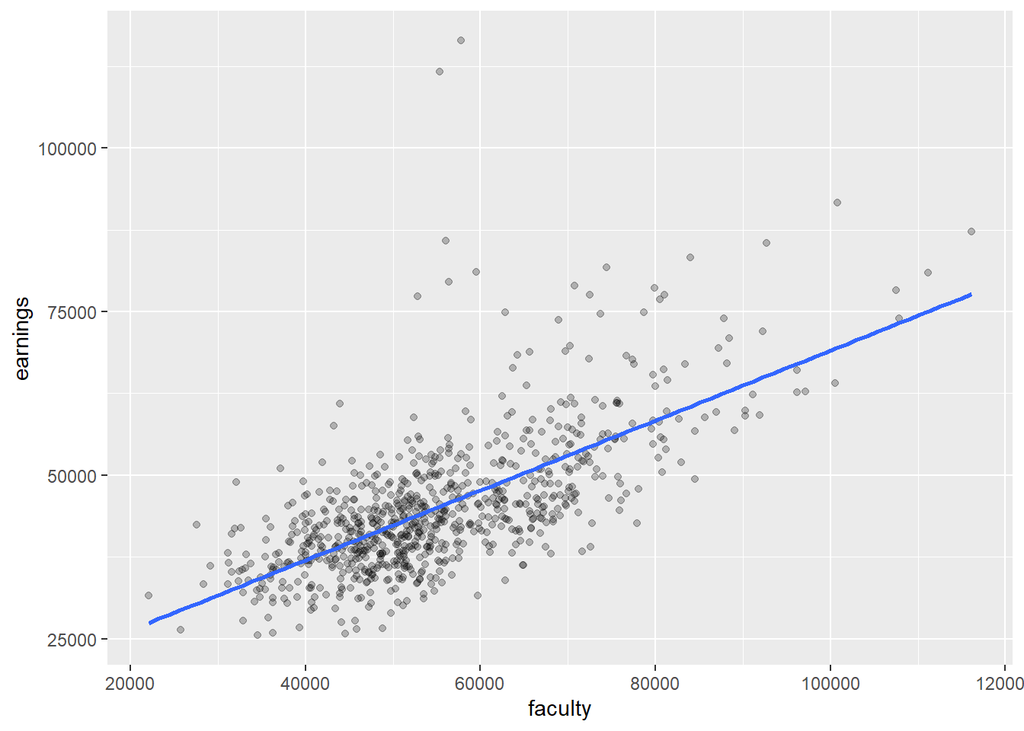

```r
ggplot(x, aes(faculty, earnings)) +
  geom_point(alpha = .25) +
  geom_smooth(method = "lm", se = FALSE)
```

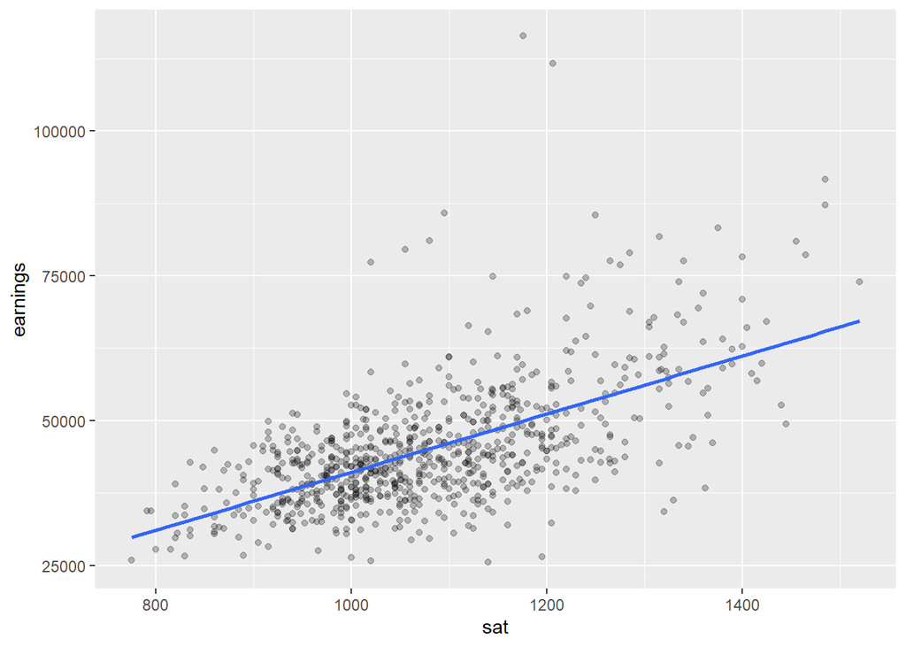

```r
ggplot(x, aes(sat, earnings)) +
  geom_point(alpha = .25) +
  geom_smooth(method = "lm", se = FALSE)
```

### Scene 4

**Prompt:** Now let’s quantify these relationships between the two explanatory variables and the outcome variable. Fit a multiple regression model for `earnings` using `sat` and `faculty` as the explanatory variables. Write a bullet point interpreting each of the three values in the estimate column. Do not use any interaction terms in the regression (yet).

```r
# "+" means the two variables do NOT interact; if you want them to use "*"

regression_model_sat_faculty <- lm(earnings ~ faculty + sat, data = x)

regression_model_sat_faculty %>%
  tidy(conf.int = TRUE) %>%
  select(term, estimate, conf.low, conf.high)
```

```
## # A tibble: 3 x 4
##   term         estimate  conf.low conf.high
##   <chr>           <dbl>     <dbl>     <dbl>
## 1 (Intercept) -2591.    -7092.     1910.
## 2 faculty         0.385     0.335     0.436
## 3 sat            24.5      19.2      29.7
```

- Holding other variables constant, an increase of 1 in faculty will result in a .38 increase in predicted student earnings.
- 95% certain: the averaqe treatment effect will be between .335 and .436 (Bayesian).

### Scene 7

**Prompt:** Recall the model we made in Scene 4: `earnings` as a function of `sat` and `faculty`.

First, re-estimate that model. Call it `model_1`.

Second, look at the regression coefficients.

Third, consider a school with average faculty salary of $50,000 and average SAT of 1200. What would the school’s median earnings be 10 years from now? Use the simple approach of taking the regression estimates and then plugging in 50 and 1200 into the formula which the regression model represents.

Fourth (and optional! not covered in the book!), check out the `predict()` function. This allows you to avoid typing out the formula yourself.

```r
model_meow <- lm(earnings ~ sat + faculty, data = x) %>%
  tidy()
```

### Scene 8

**Prompt:** We have our regression model, still called `model_1`, which uses two numerical explanatory variables.

First, use the `augment()` function to calculate the fitted values and residuals. You might want to look at some of the arguments that the `augment()` function allows for.

Second, define what the residual is.

Third, determine the school with the largest positive residual and the school with the largest negative residual.

Fourth, speculate about what causes these residuals. What is the model missing? How might we improve the model?

```r
# include

model1 <- lm(earnings ~ sat + faculty, data = x)
augment(model1, data = x) %>%
  select(name, earnings, sat, faculty, .fitted, .resid) %>%
  arrange(desc(.resid))
```

```
## # A tibble: 797 x 6
##    name                                    earnings   sat faculty .fitted .resid
##    <chr>                                      <dbl> <dbl>   <dbl>   <dbl>  <dbl>
##  1 MCPHS University                          116400 1176   57745.  48451. 67949.
##  2 Saint Louis College Of Pharmacy           111600 1206.  55336.  48270. 63330.
##  3 University Of The Sciences In Philadel~    85800 1095   56004.  45797. 40003.
##  4 SUNY Maritime College                      77300 1020   52858.  42749. 34551.
##  5 Massachusetts Maritime Academy             79500 1055   56382.  44964. 34536.
##  6 California Maritime Academy                81100 1080   59491.  46774. 34326.
##  7 Rensselaer Polytechnic Institute           81700 1315   74392.  58270. 23430.
##  8 Kettering University                       74900 1220   62818.  51484. 23416.
##  9 Rose - Hulman Institute Of Technology      78900 1285   70743.  56129. 22771.
## 10 Babson College                             85500 1250   92702.  63734. 21766.
## # ... with 787 more rows
```

### Scene 9

**Prompt:** Now that we have explored the relationships between two numerical explanatory variables and the outcome variable, let’s look at a model that involves using one categorical variable `public` and one numerical explanatory variable `price` to explain the median earnings variable. `public` is 0 if the school is private and 1 if it is not. `price` is tuition in thousands of dollars.

First, estimate a new model in which `earnings` are explained by `public` and by `price`. There is no interaction term. Interpret the regression coefficients.

Second, estimate another model, `model_2`, in which `earnings` are explained by `public`, `price` and the **interaction** between `public` and `price`. Interpret the regression coefficients.

Third, use `tidy()` to find the confidence intervals for the regression coefficients for `model_2`.

Fourth, interpret the confidence interval for coefficient on `public` using one sentence for the Bayesian interpretation and one sentence for the Frequentist interpretation.

```r
model_interaction <- lm(earnings ~ price + public + price * public, data = x)
model_interaction
```

```
##
## Call:
## lm(formula = earnings ~ price + public + price * public, data = x)
##
## Coefficients:
##  (Intercept)         price        public  price:public
##    2.398e+04     1.359e+00     1.115e+04     9.798e-01
```

### Scene 10

**Prompt:** In the previous scene, we generated the confidence intervals using `tidy(conf.int = TRUE)`. Let’s check those confidence intervals by doing our own bootstrapping. Set `reps = 100` to save processing time. Hints: `unnest()`, `group_by()`, and `summarize()` are useful here, especially `unnest()` which you may not have seen before.

In other words, you are not using `tidy(conf.int = TRUE)`. You are just using `tidy()`. That gives you the tibble of the regression estimates. Then, you can use `unnest()` to “explode” out a row for each estimate. Then, `group_by(term)` and the usual quantile trick for each parameter should give you what you want.

```r
x %>%
  rep_sample_n(size = nrow(x), reps = 100, replace = TRUE) %>%
  group_by(replicate) %>%
  nest() %>%
  mutate(mod = map(data, ~ lm(earnings ~ price * public, data = .)),
         reg_results = map(mod, ~ tidy(., conf.int = TRUE))) %>%
  unnest(reg_results) %>%
  group_by(term)
```

```
## # A tibble: 400 x 10
## # Groups:   term [4]
##    replicate data  mod   term  estimate std.error statistic  p.value conf.low
##        <int> <lis> <lis> <chr>    <dbl>     <dbl>     <dbl>    <dbl>    <dbl>
##  1         1 <tib~ <lm>  (Int~ 25177.   1232.         20.4  6.71e-75  2.28e+4
##  2         1 <tib~ <lm>  price     1.26    0.0740     17.0  1.24e-55  1.11e+0
##  3         1 <tib~ <lm>  publ~  9713.   1967.          4.94 9.58e- 7  5.85e+3
##  4         1 <tib~ <lm>  pric~     1.29    0.445       2.90 3.79e- 3  4.19e-1
##  5         2 <tib~ <lm>  (Int~ 26040.   1320.         19.7  8.11e-71  2.34e+4
##  6         2 <tib~ <lm>  price     1.24    0.0774     16.0  5.29e-50  1.08e+0
##  7         2 <tib~ <lm>  publ~  5350.   2141.          2.50 1.27e- 2  1.15e+3
##  8         2 <tib~ <lm>  pric~     2.28    0.487       4.68 3.33e- 6  1.32e+0
##  9         3 <tib~ <lm>  (Int~ 23671.   1226.         19.3  2.05e-68  2.13e+4
## 10         3 <tib~ <lm>  price     1.38    0.0737     18.7  8.22e-65  1.23e+0
## # ... with 390 more rows, and 1 more variable: conf.high <dbl>
```

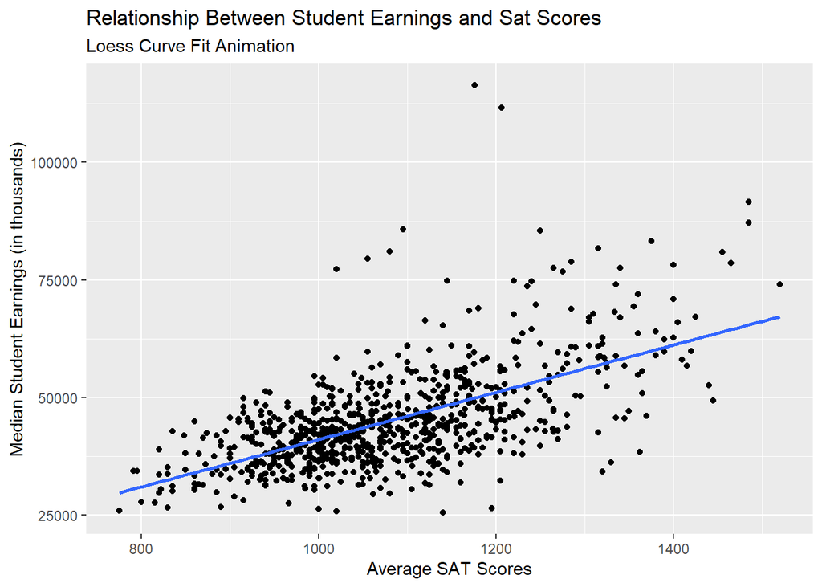

```r
# Making a gganimate plot that shows how a loess curve is fitted to a
# scatterplot of sat scores and earnings.

mod <- loess(earnings ~ sat, x, degree = 1, span = .75)

fit <- augment(mod)

pivot_points <- seq(800, 1500, 100)

x_2 <- x %>%
  select(sat, earnings) %>%
  crossing(center = pivot_points)


ggplot(x_2, aes(sat, earnings)) +
  geom_point() +
  geom_smooth(method = "lm", se = FALSE) +
  labs(x = "Average SAT Scores",
       y = "Median Student Earnings (in thousands)",
       title = "Relationship Between Student Earnings and Sat Scores",
       subtitle = "Loess Curve Fit Animation")
```